# Predict_413_Discussion_3

Singh, Gurjeet

January 24, 2018

## 1. Data

For this week’s discussion, I am using the same dataset (U.S Air Carrier Traffic Statistics – Revenue Passenger Miles) from the last week. The figure below shows that this data has strong seasonality within each year. Along with the seasonality, there is also an upward trend to it.

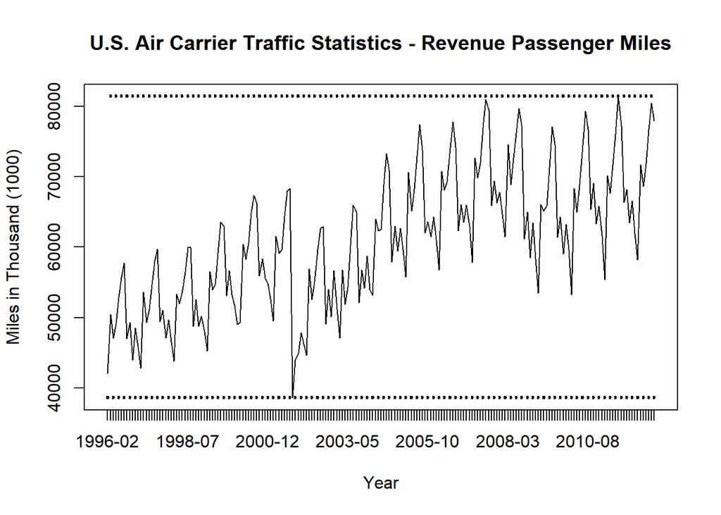

```r
#Import the data
US.air.traffic  <- read.csv("us-air-carrier-traffic-statistic.csv")
colnames(US.air.traffic) <- c("YearMonth", "Revenue_Miles")
plot(zoo(US.air.traffic$Revenue_Miles/1000, US.air.traffic$YearMonth),
        main = paste0("U.S. Air ",
                   "Carrier Traffic Statistics ",
                   "- Revenue Passenger Miles"),
        xlab = "Year",
        ylab = "Miles in Thousand (1000)")
```

### 1.1 Split Data - Training/Test set

We split the data into the training set and test set using 70/30 split approach. We will use the training set to build the model and test data for validation and check the accuracy of the model.

```r
#Split the data into training set and test set
train.df <- ts(US.air.traffic[1:139,"Revenue_Miles"], frequency = 12) #training set
test.df <- ts(US.air.traffic[140:199,"Revenue_Miles"], frequency = 12) #test set
```